# Descriptives, Coverage, and Group Composition

Master’s Thesis – Media Quality / Media Diet

2026-09-15

```r
knitr::opts_chunk$set(echo = TRUE, eval = TRUE, warning = FALSE, message = TRUE,
                      fig.width = 10, fig.height = 5)
```

# 1 Overview

Descriptive layer over the analysis dataset built by `03a`. Estimation happens in `03b`; nothing here tests a hypothesis.

| Part | Content |
| --- | --- |
| 1 | Setup, constants, helpers |
| 2 | Descriptive statistics of the analysis variables |
| 3 | Coverage by measure and wave, and the quality-coverage triage |
| 4 | Randomization balance, joint test, and covariate missingness by arm |
| 5 | Arm sizes, subgroup sizes, and their cross-tabulation |
| 6 | Distributions of the outcome, the quality measures, effort, and the habitual diet |
| 7 | Habitual quality against political position and vote intention |
| 8 | Listing of the files written |

## 1.1 Outputs

| File | Content |
| --- | --- |
| `tab_descriptives` | Analysis variables: mean, SD, min, max, median |
| `tab_coverage` | Non-missing counts by measure and wave |
| `tab_triage` | Three-way quality-coverage triage |
| `tab_balance` | Covariate means by arm and wave, with per-variable p-values |
| `tab_missingness_by_arm` | Missingness of prior engagement by arm |
| `tab_composition_arms` | Arm sizes by wave |
| `tab_composition_arm_by_diet` | Arm by habitual-quality cell sizes |
| `fig_coverage_triage` | Where the quality measure loses the sample |
| `fig_composition_arm_by_diet` | Habitual-quality composition within arms |
| `fig_quality_density` | Habitual and encountered quality distributions |
| `fig_effort_distribution` | Effort distribution by arm |
| `fig_habitual_split` | Habitual quality with the median used for the split |
| `fig_level_vs_diversity` | Level against diversity, by definition |
| `fig_moderator_leaning` | Political self-placement by habitual-quality group |
| `fig_moderator_vote` | Vote intention by habitual-quality group |
| `fig_moderator_attitude_change` | Signed attitude change by habitual-quality group |

Tables are written as LaTeX fragments and as CSV; figures as PNG.

# 2 Part 1: Setup

```r
library(dplyr)
library(tidyr)
library(purrr)
library(readr)
library(stringr)
library(ggplot2)
```

```r
WAVE_TOPICS <- c("1" = "Child support", "2" = "Energy transition", "3" = "Cannabis")
DIET_VARIANTS <- c("overall", "news", "news_corrected")
DIET_LABELS <- c(overall = "Overall scored diet", news = "Automated news diet",
                 news_corrected = "Corrected news diet")
COVARS_DESC <- c("att_baseline", "prior_engagement", "polknow_total",
                 "pol_interest_general", "newsuse_online", "edu_time",
                 "age", "gender_f")

theme_set(theme_minimal(base_size = 11))
ARM_COLOURS <- c(control = "grey60", verbal = "steelblue", monetary = "firebrick")
```

```r
write_latex_table <- function(df, file, digits = 3, caption = NULL) {
  esc <- function(x) str_replace_all(as.character(x), "([_%&#])", "\\\\\\1")
  body <- df %>%
    mutate(across(where(is.numeric), ~ formatC(.x, format = "f", digits = digits))) %>%
    mutate(across(everything(), ~ ifelse(is.na(.x) | .x == "NA", "--", esc(.x))))
  header <- paste(paste0("\\textit{", esc(names(df)), "}"), collapse = " & ")
  rows <- apply(body, 1, function(r)
    paste0("      \\textit{", r[1], "} & ", paste(r[-1], collapse = " & "), " \\\\"))
  lines <- c(paste0("\\begin{tabular}{", paste(rep("c", ncol(df)), collapse = " "), "}"),
             "      \\hline", paste0("      ", header, " \\\\"), "      \\hline",
             rows, "      \\hline", "    \\end{tabular}")
  if (!is.null(caption)) lines <- c(paste0("% ", caption), lines)
  writeLines(lines, file.path(table_dir, paste0(file, ".tex")))
  write_csv(df, file.path(table_dir, paste0(file, ".csv")))
  invisible(df)
}

save_fig <- function(p, name, width = 10, height = 5) {
  print(p)
  ggsave(file.path(fig_dir, paste0(name, ".png")), p, width = width, height = height, dpi = 300)
}
```

```r
analysis_data <- readRDS(file.path(input_dir, "analysis_data_by_wave.Rds"))

dat <- bind_rows(analysis_data) %>%
  mutate(topic = factor(WAVE_TOPICS[as.character(wave)], levels = WAVE_TOPICS))

cat("Participant-waves:", nrow(dat), "| participants:", n_distinct(dat$pid), "\n")
```

```
## Participant-waves: 1790 | participants: 791
```

# 3 Part 2: Descriptive Statistics

Table 5.1 of the Results chapter. Quality variables are summarised on the participants for whom they exist, not on the full wave, so the `N` column differs by row by design.

```r
desc_vars <- tribble(
  ~variable,             ~label,
  "y_abs",               "Attitude change (absolute)",
  "y_signed",            "Attitude change (signed)",
  "kno_signed",          "Knowledge change",
  "exp_topic_uptake_yn", "Topic-relevant uptake (0/1)",
  "effort_count",        "Topic-relevant visits",
  "topic_duration",      "Time on topic (s)",
  "q_primary",           "Encountered quality",
  "hab_overall_dw_pc1",  "Habitual quality (overall)",
  "hab_news_corrected_dw_pc1", "Habitual quality (corrected news)",
  "att_baseline",        "Baseline attitude",
  "polknow_total",       "Political knowledge",
  "pol_interest_general","Political interest",
  "newsuse_online",      "Online news use (days/week)",
  "age",                 "Age"
)

tab_desc <- desc_vars %>%
  pmap_dfr(function(variable, label) {
    x <- dat[[variable]]
    x <- x[!is.na(x)]
    tibble(Variable = label, N = length(x), Mean = mean(x), Std = sd(x),
           Minimum = min(x), Maximum = max(x), Median = median(x))
  })

print(as.data.frame(tab_desc))
```

```
##                             Variable    N       Mean          Std    Minimum
## 1         Attitude change (absolute) 1790  0.7027933   1.01136251  0.0000000
## 2           Attitude change (signed) 1790  0.0301676   1.23131557 -6.0000000
## 3                   Knowledge change 1790  0.2832402   0.78747788 -3.0000000
## 4        Topic-relevant uptake (0/1) 1790  0.2111732   0.40825505  0.0000000
## 5              Topic-relevant visits 1790  0.8793296   2.62953249  0.0000000
## 6                  Time on topic (s) 1790 62.0184358 233.62268911  0.0000000
## 7                Encountered quality  198  0.7380866   0.12372850  0.3750927
## 8         Habitual quality (overall) 1750  0.6318894   0.10599655  0.3796980
## 9  Habitual quality (corrected news) 1691  0.7127041   0.06423654  0.3044403
## 10                 Baseline attitude 1790  4.7407821   1.92127376  1.0000000
## 11               Political knowledge 1790  0.5989484   0.20732115  0.0000000
## 12                Political interest 1790  3.4262570   1.08749843  1.0000000
## 13       Online news use (days/week) 1790  4.7284916   2.82625704  0.0000000
## 14                               Age 1790 48.9000000  12.13587828 18.0000000
##         Maximum     Median
## 1     6.0000000  0.0000000
## 2     6.0000000  0.0000000
## 3     3.0000000  0.0000000
## 4     1.0000000  0.0000000
## 5    41.0000000  0.0000000
## 6  5027.0000000  0.0000000
## 7     0.9323033  0.7056154
## 8     0.9260125  0.6610502
## 9     0.9323033  0.7110398
## 10    7.0000000  5.0000000
## 11    0.9411765  0.6470588
## 12    5.0000000  3.0000000
## 13    8.0000000  5.0000000
## 14   78.0000000 50.0000000
```

```r
write_latex_table(tab_desc, "tab_descriptives", caption = "Table 5.1: descriptives")
```

```r
tab_desc_wave <- dat %>%
  group_by(Topic = topic) %>%
  summarise(N = n(),
            Uptake = mean(exp_topic_uptake_yn, na.rm = TRUE),
            Effort = median(effort_count, na.rm = TRUE),
            Quality = mean(q_primary, na.rm = TRUE),
            Attitude = mean(y_abs, na.rm = TRUE),
            .groups = "drop")

print(as.data.frame(tab_desc_wave))
```

```
##               Topic   N    Uptake Effort   Quality  Attitude
## 1     Child support 586 0.2508532      0 0.7588305 0.7952218
## 2 Energy transition 598 0.2040134      0 0.7452950 0.7441472
## 3          Cannabis 606 0.1798680      0 0.7143312 0.5726073
```

```r
write_latex_table(tab_desc_wave, "tab_descriptives_by_wave",
                  caption = "Key measures by wave")
```

# 4 Part 3: Coverage

Non-missing counts per measure and wave. Uptake and the outcomes are complete by construction; the quality measures and the habitual measures are not.

```r
tab_coverage <- dat %>%
  group_by(Topic = topic) %>%
  summarise(
    N              = n(),
    Outcome        = sum(!is.na(y_abs)),
    Uptake         = sum(!is.na(exp_topic_uptake_yn)),
    `Any uptake`   = sum(exp_topic_uptake_yn == 1, na.rm = TRUE),
    `Quality (primary)`      = sum(!is.na(q_primary)),
    `Quality (news)`         = sum(!is.na(exp_q_dur_news)),
    `Quality (incl. search)` = sum(!is.na(exp_q_dur_all)),
    `Habitual (overall)`     = sum(!is.na(hab_overall_dw_pc1)),
    `Habitual (auto news)`   = sum(!is.na(hab_news_dw_pc1)),
    `Habitual (corr. news)`  = sum(!is.na(hab_news_corrected_dw_pc1)),
    # The covariate set is not complete, so adjusted models rest on fewer rows.
    `Covariate-complete`     = sum(if_all(all_of(COVARS_DESC), ~ !is.na(.x))),
    .groups = "drop"
  )


print(as.data.frame(tab_coverage))
```

```
##               Topic   N Outcome Uptake Any uptake Quality (primary)
## 1     Child support 586     586    586        147                89
## 2 Energy transition 598     598    598        122                24
## 3          Cannabis 606     606    606        109                85
##   Quality (news) Quality (incl. search) Habitual (overall) Habitual (auto news)
## 1             81                    136                575                  489
## 2             13                     93                582                  494
## 3             55                    108                593                  501
##   Habitual (corr. news) Covariate-complete
## 1                   556                558
## 2                   563                565
## 3                   572                567
```

```r
write_latex_table(tab_coverage, "tab_coverage", digits = 0,
                  caption = "Coverage by measure and wave")
```

Three groups: no topic-relevant activity, activity without a scored domain, and at least one scored domain.

```r
tab_triage <- dat %>%
  mutate(Group = case_when(
    exp_topic_uptake_yn == 0 ~ "1: No topic-relevant activity",
    is.na(q_primary)         ~ "2: Activity, no scored domain",
    TRUE                     ~ "3: At least one scored domain")) %>%
  count(Topic = topic, Group) %>%
  group_by(Topic) %>%
  mutate(Share = round(100 * n / sum(n), 1)) %>%
  ungroup() %>%
  rename(N = n)

print(as.data.frame(tab_triage))
```

```
##               Topic                         Group   N Share
## 1     Child support 1: No topic-relevant activity 439  74.9
## 2     Child support 2: Activity, no scored domain  58   9.9
## 3     Child support 3: At least one scored domain  89  15.2
## 4 Energy transition 1: No topic-relevant activity 476  79.6
## 5 Energy transition 2: Activity, no scored domain  98  16.4
## 6 Energy transition 3: At least one scored domain  24   4.0
## 7          Cannabis 1: No topic-relevant activity 497  82.0
## 8          Cannabis 2: Activity, no scored domain  24   4.0
## 9          Cannabis 3: At least one scored domain  85  14.0
```

```r
write_latex_table(tab_triage, "tab_triage", digits = 1,
                  caption = "Quality-coverage triage")
```

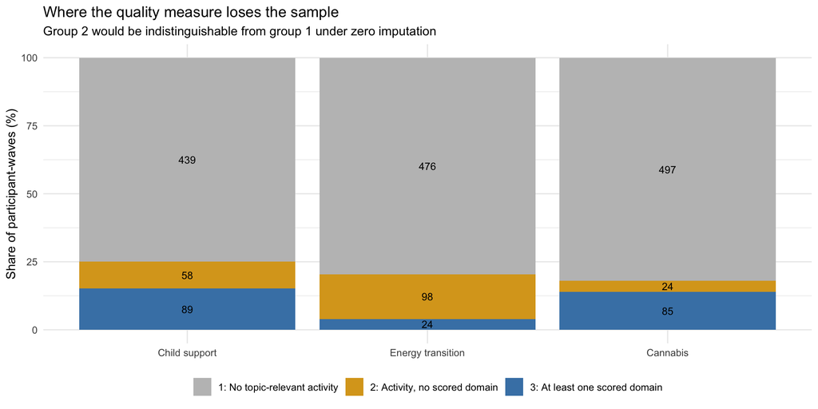

```r
p_triage <- tab_triage %>%
  ggplot(aes(x = Topic, y = Share, fill = Group)) +
  geom_col() +
  geom_text(aes(label = N), position = position_stack(vjust = .5), size = 3.2) +
  scale_fill_manual(values = c("grey75", "goldenrod", "steelblue")) +
  labs(title = "Where the quality measure loses the sample",
       subtitle = "Group 2 would be indistinguishable from group 1 under zero imputation",
       y = "Share of participant-waves (%)", x = NULL, fill = NULL) +
  theme(legend.position = "bottom")

save_fig(p_triage, "fig_coverage_triage", height = 5)
```

# 5 Part 4: Randomization Balance

Per-variable means and p-values by arm for each wave, a joint test of assignment on the covariate set, and the missingness of the one incomplete covariate by arm.

```r
balance_vars <- c("att_baseline", "prior_engagement", "polknow_total",
                  "pol_interest_general", "newsuse_online", "edu_time", "age",
                  "hab_overall_dw_pc1")
# Each wave randomizes separately, so balance is computed per wave.
balance_one <- function(w) {
  d <- filter(dat, wave == w)
  means <- d %>%
    dplyr::select(group_f, all_of(balance_vars)) %>%
    pivot_longer(-group_f, names_to = "Variable") %>%
    group_by(Variable, group_f) %>%
    summarise(m = mean(value, na.rm = TRUE), .groups = "drop") %>%
    pivot_wider(names_from = group_f, values_from = m)

  pvals <- map_dfr(balance_vars, ~ tibble(
    Variable = .x,
    p = summary(aov(reformulate("group_f", .x), data = d))[[1]][["Pr(>F)"]][1]))

  means %>% left_join(pvals, by = "Variable") %>%
    mutate(Topic = WAVE_TOPICS[as.character(w)], .before = 1)
}

tab_balance <- map_dfr(1:3, balance_one) %>%
  mutate(across(where(is.numeric), ~ round(.x, 3)))

cat("Covariate balance across arms, by wave:\n")
```

```
## Covariate balance across arms, by wave:
```

```r
print(as.data.frame(tab_balance))
```

```
##                Topic             Variable control verbal monetary     p
## 1      Child support                  age  49.212 49.585   48.138 0.464
## 2      Child support         att_baseline   4.995  4.835    4.866 0.636
## 3      Child support             edu_time  14.332 14.403   14.433 0.965
## 4      Child support   hab_overall_dw_pc1   0.630  0.627    0.634 0.798
## 5      Child support       newsuse_online   4.917  4.511    4.631 0.365
## 6      Child support pol_interest_general   3.482  3.369    3.488 0.501
## 7      Child support        polknow_total   0.615  0.577    0.595 0.229
## 8      Child support     prior_engagement   0.351  0.251    0.257 0.059
## 9  Energy transition                  age  48.072 49.290   49.268 0.526
## 10 Energy transition         att_baseline   5.289  5.271    5.337 0.916
## 11 Energy transition             edu_time  14.309 14.262   14.563 0.686
## 12 Energy transition   hab_overall_dw_pc1   0.622  0.634    0.641 0.229
## 13 Energy transition       newsuse_online   4.588  4.780    4.926 0.495
## 14 Energy transition pol_interest_general   3.356  3.388    3.547 0.175
## 15 Energy transition        polknow_total   0.613  0.595    0.607 0.655
## 16 Energy transition     prior_engagement   0.535  0.556    0.505 0.615
## 17          Cannabis                  age  48.043 49.464   49.172 0.454
## 18          Cannabis         att_baseline   3.918  4.010    4.198 0.419
## 19          Cannabis             edu_time  14.266 14.357   14.500 0.818
## 20          Cannabis   hab_overall_dw_pc1   0.628  0.633    0.638 0.624
## 21          Cannabis       newsuse_online   4.783  4.686    4.724 0.941
## 22          Cannabis pol_interest_general   3.386  3.367    3.453 0.713
## 23          Cannabis        polknow_total   0.605  0.589    0.593 0.723
## 24          Cannabis     prior_engagement   0.411  0.421    0.350 0.321
```

```r
# Joint test of assignment on the covariate set, alongside the per-variable
# tests above.
cat("\nJoint test of assignment on the covariate set:\n")
```

```
##
## Joint test of assignment on the covariate set:
```

```r
map_dfr(1:3, function(w) {
  d <- filter(dat, wave == w) %>% filter(if_all(all_of(balance_vars), ~ !is.na(.x)))
  fit <- lm(reformulate(balance_vars, "as.integer(group_f == 'monetary')"), data = d)
  f <- summary(fit)$fstatistic
  tibble(Topic = WAVE_TOPICS[as.character(w)], N = nrow(d),
         F = round(f[1], 2),
         p = round(pf(f[1], f[2], f[3], lower.tail = FALSE), 3))
}) %>% as.data.frame() %>% print()
```

```
##               Topic   N    F     p
## 1     Child support 547 0.87 0.543
## 2 Energy transition 549 1.11 0.351
## 3          Cannabis 554 0.86 0.549
```

```r
write_latex_table(tab_balance, "tab_balance", caption = "Covariate balance by wave")
```

```r
# prior_engagement is the only covariate with missing values. Its missingness
# is tested against arm, since adjusted models drop those rows.
miss_by_arm <- dat %>%
  group_by(Topic = topic, Arm = group_f) %>%
  summarise(n = n(),
            n_missing = sum(is.na(prior_engagement)),
            pct = round(100 * mean(is.na(prior_engagement)), 1),
            .groups = "drop")

cat("Missingness of prior_engagement by arm:\n")
```

```
## Missingness of prior_engagement by arm:
```

```r
print(as.data.frame(miss_by_arm))
```

```
##               Topic      Arm   n n_missing pct
## 1     Child support  control 193         8 4.1
## 2     Child support   verbal 176         9 5.1
## 3     Child support monetary 217        11 5.1
## 4 Energy transition  control 194         7 3.6
## 5 Energy transition   verbal 214        18 8.4
## 6 Energy transition monetary 190         8 4.2
## 7          Cannabis  control 207        10 4.8
## 8          Cannabis   verbal 207        17 8.2
## 9          Cannabis monetary 192        12 6.2
```

```r
miss_test <- dat %>%
  group_by(Topic = topic) %>%
  summarise(p = chisq.test(table(group_f, is.na(prior_engagement)))$p.value,
            .groups = "drop") %>%
  mutate(p = round(p, 3))

cat("\nChi-squared test of missingness against arm:\n")
```

```
##
## Chi-squared test of missingness against arm:
```

```r
print(as.data.frame(miss_test))
```

```
##               Topic     p
## 1     Child support 0.881
## 2 Energy transition 0.067
## 3          Cannabis 0.371
```

```r
write_latex_table(miss_by_arm, "tab_missingness_by_arm", digits = 1,
                  caption = "Missingness of prior engagement by treatment arm")
```

# 6 Part 5: Group Composition

Arm sizes, habitual-quality subgroup sizes, and the cross-tabulation of the two, with chi-squared tests of independence between arm and subgroup.

```r
tab_arms <- dat %>%
  count(Topic = topic, Arm = group_f) %>%
  pivot_wider(names_from = Arm, values_from = n, values_fill = 0L) %>%
  mutate(Total = rowSums(across(where(is.numeric))))

print(as.data.frame(tab_arms))
```

```
##               Topic control verbal monetary Total
## 1     Child support     193    176      217   586
## 2 Energy transition     194    214      190   598
## 3          Cannabis     207    207      192   606
```

```r
write_latex_table(tab_arms, "tab_composition_arms", digits = 0,
                  caption = "Arm sizes by wave")
```

```r
tab_diet <- map_dfr(DIET_VARIANTS, function(v) {
  dat %>%
    count(Topic = topic, Group = .data[[paste0("hab_", v, "_level_group")]]) %>%
    mutate(Definition = DIET_LABELS[[v]])
}) %>%
  mutate(Group = as.character(Group),
         Group = if_else(is.na(Group), "missing", Group)) %>%
  pivot_wider(names_from = Group, values_from = n, values_fill = 0L)

print(as.data.frame(tab_diet))
```

```
##               Topic          Definition low high missing
## 1     Child support Overall scored diet 292  283      11
## 2 Energy transition Overall scored diet 298  284      16
## 3          Cannabis Overall scored diet 301  292      13
## 4     Child support Automated news diet 246  243      97
## 5 Energy transition Automated news diet 245  249     104
## 6          Cannabis Automated news diet 248  253     105
## 7     Child support Corrected news diet 272  284      30
## 8 Energy transition Corrected news diet 283  280      35
## 9          Cannabis Corrected news diet 280  292      34
```

```r
write_latex_table(tab_diet, "tab_composition_diet", digits = 0,
                  caption = "Habitual-quality subgroup sizes")
```

```r
tab_cross <- map_dfr(DIET_VARIANTS, function(v) {
  dat %>%
    filter(!is.na(.data[[paste0("hab_", v, "_level_group")]])) %>%
    count(Topic = topic, Arm = group_f,
          Diet = .data[[paste0("hab_", v, "_level_group")]]) %>%
    mutate(Definition = DIET_LABELS[[v]])
}) %>%
  unite("Cell", Arm, Diet, sep = " / ") %>%
  pivot_wider(names_from = Cell, values_from = n, values_fill = 0L)

cat("Arm x habitual-quality cell sizes:\n")
```

```
## Arm x habitual-quality cell sizes:
```

```r
print(as.data.frame(tab_cross))
```

```
##               Topic          Definition control / low control / high
## 1     Child support Overall scored diet            99             90
## 2 Energy transition Overall scored diet           104             85
## 3          Cannabis Overall scored diet           110             94
## 4     Child support Automated news diet            80             77
## 5 Energy transition Automated news diet            82             73
## 6          Cannabis Automated news diet            90             82
## 7     Child support Corrected news diet            87             94
## 8 Energy transition Corrected news diet            92             87
## 9          Cannabis Corrected news diet           101             91
##   verbal / low verbal / high monetary / low monetary / high
## 1           90            84            103             109
## 2          102           106             92              93
## 3           98           105             93              93
## 4           80            73             86              93
## 5           93            85             70              91
## 6           85            87             73              84
## 7           85            86            100             104
## 8           96           106             95              87
## 9           92           107             87              94
```

```r
write_latex_table(tab_cross, "tab_composition_arm_by_diet", digits = 0,
                  caption = "Arm by habitual-quality cells")

# Chi-squared test of arm against habitual-quality group, per definition
# and wave.
cat("\nChi-squared tests of arm against habitual-quality group:\n")
```

```
##
## Chi-squared tests of arm against habitual-quality group:
```

```r
map_dfr(DIET_VARIANTS, function(v) {
  map_dfr(names(WAVE_TOPICS), function(w) {
    d <- filter(dat, wave == as.integer(w), !is.na(.data[[paste0("hab_", v, "_level_group")]]))
    tt <- table(d$group_f, d[[paste0("hab_", v, "_level_group")]])
    tibble(Definition = DIET_LABELS[[v]], Topic = WAVE_TOPICS[[w]],
           p = round(suppressWarnings(chisq.test(tt)$p.value), 3))
  })
}) %>% as.data.frame() %>% print()
```

```
##            Definition             Topic     p
## 1 Overall scored diet     Child support 0.717
## 2 Overall scored diet Energy transition 0.437
## 3 Overall scored diet          Cannabis 0.507
## 4 Automated news diet     Child support 0.729
## 5 Automated news diet Energy transition 0.166
## 6 Automated news diet          Cannabis 0.572
## 7 Corrected news diet     Child support 0.953
## 8 Corrected news diet Energy transition 0.616
## 9 Corrected news diet          Cannabis 0.434
```

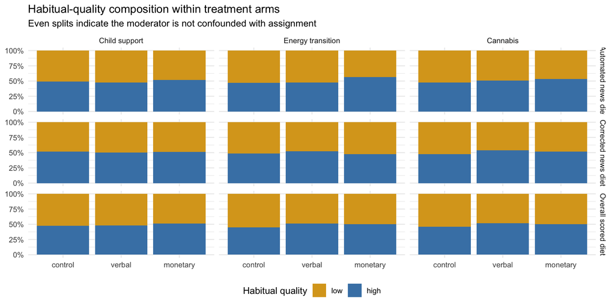

```r
p_comp <- map_dfr(DIET_VARIANTS, function(v) {
  dat %>%
    filter(!is.na(.data[[paste0("hab_", v, "_level_group")]])) %>%
    count(topic, group_f, Diet = .data[[paste0("hab_", v, "_level_group")]]) %>%
    mutate(Definition = DIET_LABELS[[v]])
}) %>%
  ggplot(aes(x = group_f, y = n, fill = Diet)) +
  geom_col(position = "fill") +
  facet_grid(Definition ~ topic) +
  scale_fill_manual(values = c(low = "goldenrod", high = "steelblue")) +
  scale_y_continuous(labels = scales::percent) +
  labs(title = "Habitual-quality composition within treatment arms",
       subtitle = "Even splits indicate the moderator is not confounded with assignment",
       x = NULL, y = NULL, fill = "Habitual quality") +
  theme(legend.position = "bottom")

save_fig(p_comp, "fig_composition_arm_by_diet", height = 7)
```

# 7 Part 6: Distributions

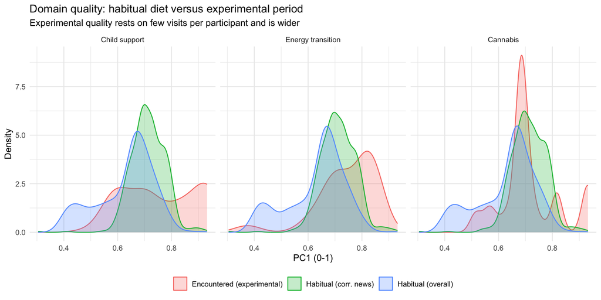

```r
p_q <- dat %>%
  dplyr::select(topic, `Habitual (overall)` = hab_overall_dw_pc1,
         `Habitual (corr. news)` = hab_news_corrected_dw_pc1,
         `Encountered (experimental)` = q_primary) %>%
  pivot_longer(-topic, names_to = "Measure", values_to = "pc1") %>%
  filter(!is.na(pc1)) %>%
  ggplot(aes(x = pc1, fill = Measure, colour = Measure)) +
  geom_density(alpha = .25) +
  facet_wrap(~ topic, nrow = 1) +
  labs(title = "Domain quality: habitual diet versus experimental period",
       subtitle = "Experimental quality rests on few visits per participant and is wider",
       x = "PC1 (0-1)", y = "Density", fill = NULL, colour = NULL) +
  theme(legend.position = "bottom")

save_fig(p_q, "fig_quality_density")
```

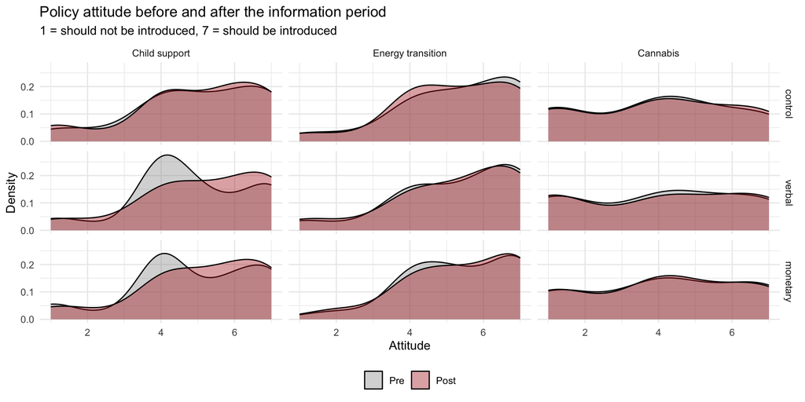

```r
p_att <- dat %>%
  dplyr::select(topic, group_f, Pre = att_baseline, Post = att_post) %>%
  pivot_longer(c(Pre, Post), names_to = "Block", values_to = "attitude") %>%
  mutate(Block = factor(Block, levels = c("Pre", "Post"))) %>%
  ggplot(aes(x = attitude, fill = Block)) +
  geom_density(alpha = .4, adjust = 1.4) +
  facet_grid(group_f ~ topic) +
  scale_fill_manual(values = c(Pre = "grey60", Post = "firebrick")) +
  labs(title = "Policy attitude before and after the information period",
       subtitle = "1 = should not be introduced, 7 = should be introduced",
       x = "Attitude", y = "Density", fill = NULL) +
  theme(legend.position = "bottom")

save_fig(p_att, "fig_attitude_density", height = 7)
```

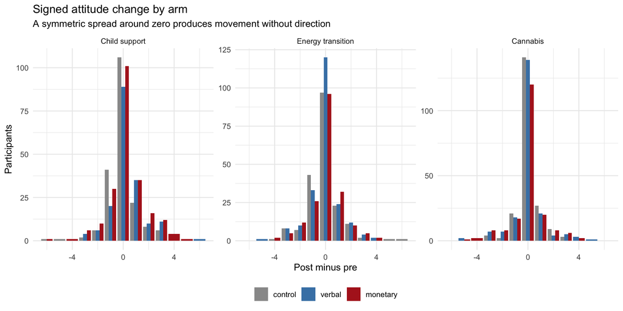

```r
p_chg <- dat %>%
  filter(!is.na(y_signed)) %>%
  ggplot(aes(x = y_signed, fill = group_f)) +
  geom_bar(position = "dodge") +
  facet_wrap(~ topic, nrow = 1, scales = "free_y") +
  scale_fill_manual(values = ARM_COLOURS) +
  labs(title = "Signed attitude change by arm",
       subtitle = "A symmetric spread around zero produces movement without direction",
       x = "Post minus pre", y = "Participants", fill = NULL) +
  theme(legend.position = "bottom")

save_fig(p_chg, "fig_attitude_change")
```

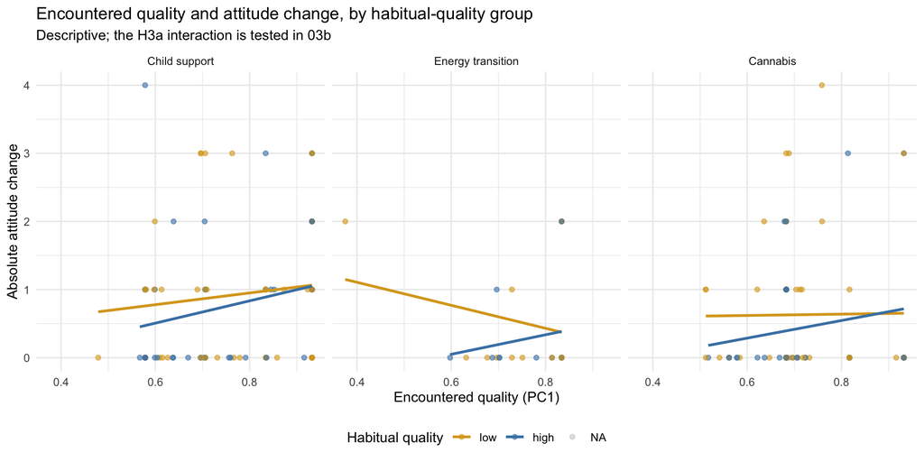

```r
p_qa <- dat %>%
  filter(!is.na(q_primary), !is.na(y_abs)) %>%
  ggplot(aes(x = q_primary, y = y_abs)) +
  geom_point(aes(colour = hab_overall_level_group), alpha = .6) +
  geom_smooth(aes(colour = hab_overall_level_group), method = "lm", se = FALSE) +
  facet_wrap(~ topic, nrow = 1) +
  scale_colour_manual(values = c(low = "goldenrod", high = "steelblue"),
                      na.value = "grey80") +
  labs(title = "Encountered quality and attitude change, by habitual-quality group",
       subtitle = "Descriptive; the H3a interaction is tested in 03b",
       x = "Encountered quality (PC1)", y = "Absolute attitude change",
       colour = "Habitual quality") +
  theme(legend.position = "bottom")

save_fig(p_qa, "fig_quality_vs_attitude")
```

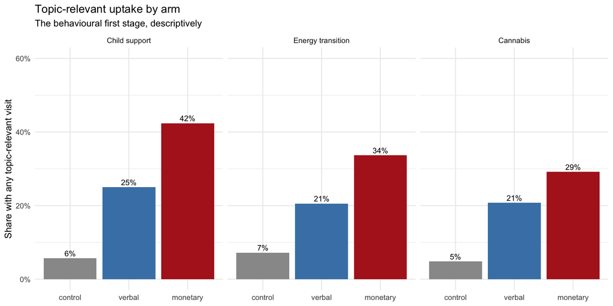

```r
p_up <- dat %>%
  group_by(topic, group_f) %>%
  summarise(rate = mean(exp_topic_uptake_yn, na.rm = TRUE),
            n = n(), .groups = "drop") %>%
  ggplot(aes(x = group_f, y = rate, fill = group_f)) +
  geom_col() +
  geom_text(aes(label = paste0(round(100 * rate), "%")), vjust = -.4, size = 3.2) +
  facet_wrap(~ topic, nrow = 1) +
  scale_fill_manual(values = ARM_COLOURS, guide = "none") +
  scale_y_continuous(labels = scales::percent, limits = c(0, .6)) +
  labs(title = "Topic-relevant uptake by arm",
       subtitle = "The behavioural first stage, descriptively",
       x = NULL, y = "Share with any topic-relevant visit")

save_fig(p_up, "fig_uptake_by_arm")
```

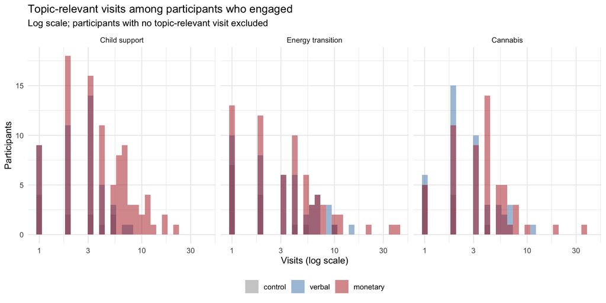

```r
p_eff <- dat %>%
  filter(exp_topic_uptake_yn == 1) %>%
  ggplot(aes(x = effort_count, fill = group_f)) +
  geom_histogram(bins = 30, position = "identity", alpha = .5) +
  facet_wrap(~ topic, nrow = 1) +
  scale_x_log10() +
  scale_fill_manual(values = ARM_COLOURS) +
  labs(title = "Topic-relevant visits among participants who engaged",
       subtitle = "Log scale; participants with no topic-relevant visit excluded",
       x = "Visits (log scale)", y = "Participants", fill = NULL) +
  theme(legend.position = "bottom")

save_fig(p_eff, "fig_effort_distribution")
```

Level and diversity of the habitual diet, with the medians that define the subgroups. Level is the duration-weighted mean PC1, diversity its duration-weighted standard deviation; both are participant-level and constant across waves.

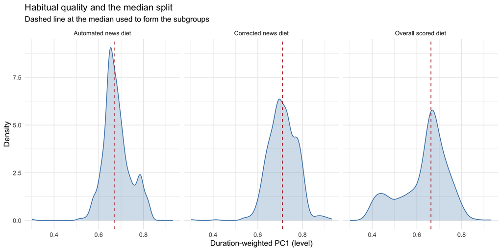

```r
p_hab <- map_dfr(DIET_VARIANTS, function(v) {
  dat %>%
    distinct(pid, .keep_all = TRUE) %>%
    transmute(Definition = DIET_LABELS[[v]],
              pc1 = .data[[paste0("hab_", v, "_dw_pc1")]])
}) %>%
  filter(!is.na(pc1))

p_hab_med <- p_hab %>%
  group_by(Definition) %>%
  summarise(m = median(pc1), .groups = "drop")

p_habitual_split <- p_hab %>%
  ggplot(aes(x = pc1)) +
  geom_density(fill = "steelblue", alpha = .25, colour = "steelblue") +
  geom_vline(data = p_hab_med, aes(xintercept = m),
             linetype = "dashed", colour = "firebrick") +
  facet_wrap(~ Definition, nrow = 1) +
  labs(title = "Habitual quality and the median split",
       subtitle = "Dashed line at the median used to form the subgroups",
       x = "Duration-weighted PC1 (level)", y = "Density")

print(p_habitual_split)
```

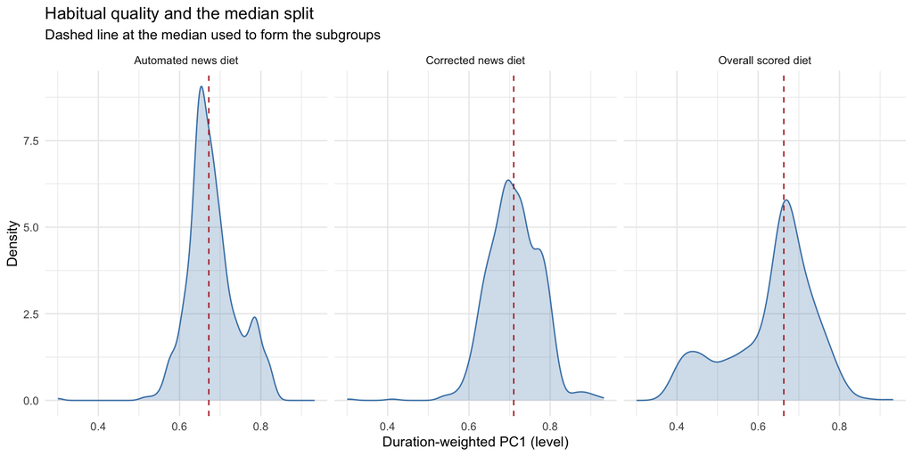

```r
save_fig(p_habitual_split, "fig_habitual_split", width = 11, height = 4)
```

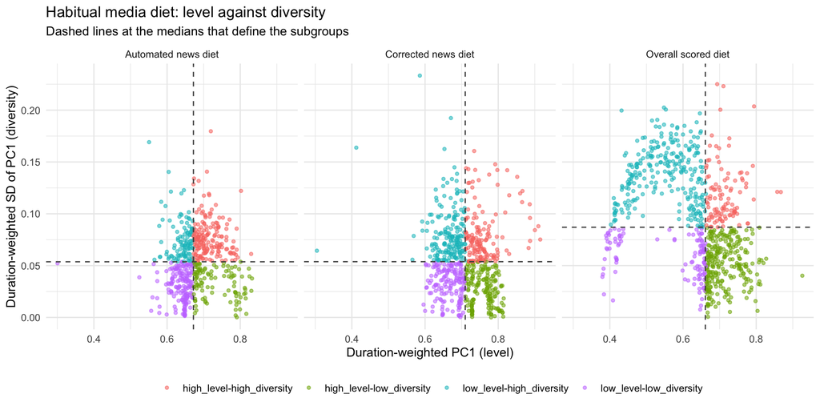

```r
# Level against diversity per definition, with the two medians that define the
# four subgroups.
lvl_div <- map_dfr(DIET_VARIANTS, function(v) {
  dat %>%
    distinct(pid, .keep_all = TRUE) %>%
    transmute(Definition = DIET_LABELS[[v]],
              level     = .data[[paste0("hab_", v, "_dw_pc1")]],
              diversity = .data[[paste0("hab_", v, "_dw_sd_pc1")]],
              Subgroup  = .data[[paste0("hab_", v, "_level_diversity_group")]])
}) %>%
  filter(!is.na(level), !is.na(diversity), !is.na(Subgroup))

lvl_div_med <- lvl_div %>%
  group_by(Definition) %>%
  summarise(m_level = median(level), m_div = median(diversity), .groups = "drop")

p_level_vs_diversity <- lvl_div %>%
  ggplot(aes(x = level, y = diversity, colour = Subgroup)) +
  geom_point(alpha = .55, size = 1.1) +
  geom_vline(data = lvl_div_med, aes(xintercept = m_level),
             linetype = "dashed", colour = "grey30") +
  geom_hline(data = lvl_div_med, aes(yintercept = m_div),
             linetype = "dashed", colour = "grey30") +
  facet_wrap(~ Definition, nrow = 1) +
  labs(title = "Habitual media diet: level against diversity",
       subtitle = "Dashed lines at the medians that define the subgroups",
       x = "Duration-weighted PC1 (level)",
       y = "Duration-weighted SD of PC1 (diversity)",
       colour = NULL) +
  theme(legend.position = "bottom")

print(p_level_vs_diversity)
```

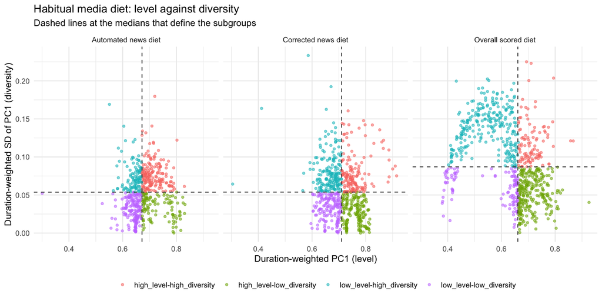

```r
save_fig(p_level_vs_diversity, "fig_level_vs_diversity", width = 11, height = 4.5)
```

```r
# Correlation between the two dimensions, per definition.
lvl_div %>%
  group_by(Definition) %>%
  summarise(n = n(),
            r = round(cor(level, diversity, use = "complete.obs"), 3),
            .groups = "drop") %>%
  as.data.frame() %>% print()
```

```
##            Definition   n      r
## 1 Automated news diet 555  0.077
## 2 Corrected news diet 673 -0.106
## 3 Overall scored diet 746 -0.380
```

# 8 Part 7: Habitual Quality against Political Position

The moderation models treat habitual news quality as a media-exposure trait. This part compares the habitual-quality groups on left-right self-placement and on reported vote intention. Both variables are measured before treatment, so all arms are included.

```r
meta_raw <- readRDS(file.path(panelist_dir, "panelist_metadata_final.Rds"))

cat("Rows:", nrow(meta_raw), "| unique pids:", n_distinct(meta_raw$pid), "\n\n")
```

```
## Rows: 2446 | unique pids: 2446
```

```r
print(grep("vot|party|partei|wahl|leaning|ideo|links|rechts|^pol", names(meta_raw),
           value = TRUE, ignore.case = TRUE))
```

```
##  [1] "pol_source_n_used"         "pol_source_primary"
##  [3] "pol_source_offline_n_used" "pol_source_online_n_used"
##  [5] "pol_source_socmed"         "pol_source_messenger"
##  [7] "pol_source_conversation"   "pol_source_other"
##  [9] "pol_source_none"           "pol_debate"
## [11] "pol_debate_online"         "pol_interest_general"
## [13] "polknow_total"             "pol_attitude"
## [15] "polpart_onl_total"         "polpart_off_total"
## [17] "voting_decision_f"         "voting_decision_y"
## [19] "election_voted"
```

```r
LEANING_VAR <- "pol_attitude"      # left-right self-placement
VOTE_VAR    <- "voting_decision_f"   # party, categorical
MOD_VARIANT <- "news_corrected"    # diet definition carrying the moderation tests
MOD_LEVELS  <- "median"          # "median" for the analysis split, "quartile" for four curves

meta <- readRDS(file.path(panelist_dir, "panelist_metadata_final.Rds")) %>%
  mutate(pid = as.character(pid)) %>%
  dplyr::select(pid, all_of(c(LEANING_VAR, VOTE_VAR))) %>%
  distinct(pid, .keep_all = TRUE)

n_before <- nrow(dat)
dat_pol <- dat %>% left_join(meta, by = "pid")
stopifnot(nrow(dat_pol) == n_before)

cat("Coverage of the joined variables:\n")
```

```
## Coverage of the joined variables:
```

```r
dat_pol %>%
  summarise(across(all_of(c(LEANING_VAR, VOTE_VAR)),
                   list(n = ~ sum(!is.na(.x)), pct = ~ round(100 * mean(!is.na(.x)), 1)))) %>%
  as.data.frame() %>% print()
```

```
##   pol_attitude_n pol_attitude_pct voting_decision_f_n voting_decision_f_pct
## 1           1790              100                1790                   100
```

Grouping variable for the figures below. `MOD_LEVELS` switches between the median split used in the models and a quartile split.

```r
hab_var <- paste0("hab_", MOD_VARIANT, "_dw_pc1")

dat_pol <- dat_pol %>%
  mutate(Diet = if (MOD_LEVELS == "quartile") {
    cut(.data[[hab_var]],
        breaks = quantile(.data[[hab_var]], probs = seq(0, 1, .25), na.rm = TRUE),
        labels = c("Q1 lowest", "Q2", "Q3", "Q4 highest"),
        include.lowest = TRUE)
  } else {
    factor(.data[[paste0("hab_", MOD_VARIANT, "_level_group")]],
           levels = c("low", "high"), labels = c("Low", "High"))
  })

DIET_COLOURS <- if (nlevels(dat_pol$Diet) == 2) {
  c("Low" = "firebrick", "High" = "steelblue")
} else {
  setNames(c("firebrick", "darkorange", "darkgreen", "steelblue"),
           levels(dat_pol$Diet))
}

cat("\nCell sizes by habitual-quality group and wave:\n")
```

```
##
## Cell sizes by habitual-quality group and wave:
```

```r
dat_pol %>% count(topic, Diet) %>%
  pivot_wider(names_from = Diet, values_from = n, values_fill = 0L) %>%
  as.data.frame() %>% print()
```

```
##               topic Low High NA
## 1     Child support 272  284 30
## 2 Energy transition 283  280 35
## 3          Cannabis 280  292 34
```

Two plot helpers: a density for continuous variables and a dodged bar chart for categorical ones. Both colour by the habitual-quality group.

```r
plot_density <- function(d, var, title, subtitle, xlab, facet_wave = TRUE, bw = 0.8) {
  p <- d %>%
    rename(x = all_of(var)) %>%
    filter(!is.na(x), !is.na(Diet)) %>%
    ggplot(aes(x = x, colour = Diet)) +
    geom_density(linewidth = .8, bw = bw) +
    scale_colour_manual(values = DIET_COLOURS) +
    labs(title = title, subtitle = subtitle, x = xlab, y = "Density",
         colour = "Habitual news quality") +
    theme(legend.position = "right")
  if (facet_wave) p + facet_wrap(~ topic, ncol = 1, scales = "free_y") else p
}

plot_composition <- function(d, var, title, subtitle, xlab) {
  d %>%
    rename(Category = all_of(var)) %>%
    filter(!is.na(Category), !is.na(Diet)) %>%
    count(Diet, Category) %>%
    group_by(Diet) %>% mutate(Share = 100 * n / sum(n)) %>% ungroup() %>%
    ggplot(aes(x = Category, y = Share, fill = Diet)) +
    geom_col(position = position_dodge(width = .8), width = .75) +
    scale_fill_manual(values = DIET_COLOURS) +
    labs(title = title, subtitle = subtitle, x = xlab,
         y = "Share within habitual-quality group (%)",
         fill = "Habitual news quality") +
    theme(axis.text.x = element_text(angle = 30, hjust = 1),
          legend.position = "right")
}
```

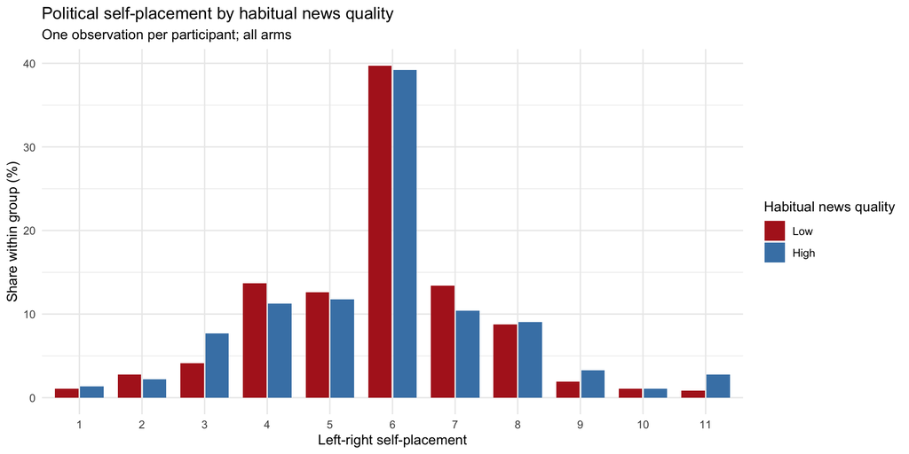

```r
p_leaning <- dat_pol %>%
  distinct(pid, .keep_all = TRUE) %>%
  rename(x = all_of(LEANING_VAR)) %>%
  filter(!is.na(x), !is.na(Diet)) %>%
  count(Diet, x) %>%
  group_by(Diet) %>% mutate(Share = 100 * n / sum(n)) %>% ungroup() %>%
  ggplot(aes(x = factor(x), y = Share, fill = Diet)) +
  geom_col(position = position_dodge(width = .8), width = .75) +
  scale_fill_manual(values = DIET_COLOURS) +
  labs(title = "Political self-placement by habitual news quality",
       subtitle = "One observation per participant; all arms",
       x = "Left-right self-placement", y = "Share within group (%)",
       fill = "Habitual news quality")

save_fig(p_leaning, "fig_moderator_leaning", height = 4)
```

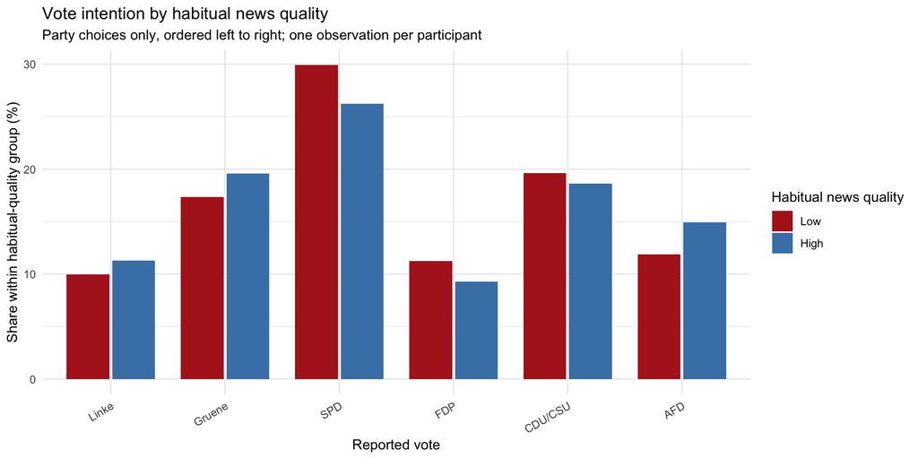

```r
# Vote intention, party choices only, ordered left to right.
PARTY_ORDER <- c("Linke", "Gruene", "SPD", "FDP", "CDU/CSU", "AFD")

p_vote <- dat_pol %>%
  distinct(pid, .keep_all = TRUE) %>%
  filter(.data[[VOTE_VAR]] %in% PARTY_ORDER) %>%
  mutate(across(all_of(VOTE_VAR), ~ factor(.x, levels = PARTY_ORDER))) %>%
  plot_composition(VOTE_VAR,
                   "Vote intention by habitual news quality",
                   "Party choices only, ordered left to right; one observation per participant",
                   "Reported vote")
p_vote <- dat_pol %>%
  distinct(pid, .keep_all = TRUE) %>%
  filter(.data[[VOTE_VAR]] %in% PARTY_ORDER) %>%
  mutate(across(all_of(VOTE_VAR), ~ factor(.x, levels = PARTY_ORDER))) %>%
  plot_composition(VOTE_VAR,
                   "Vote intention by habitual news quality",
                   "Party choices only, ordered left to right; one observation per participant",
                   "Reported vote")



save_fig(p_vote, "fig_moderator_vote", height = 5)
```

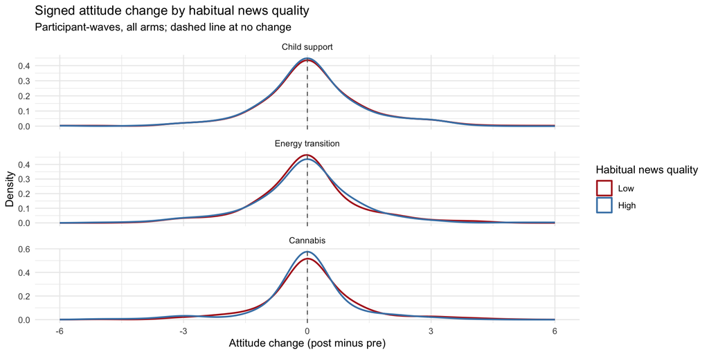

```r
# Signed attitude change by habitual-quality group, faceted by wave.
p_change <- dat_pol %>%
  plot_density("y_signed",
               "Signed attitude change by habitual news quality",
               "Participant-waves, all arms; dashed line at no change",
               "Attitude change (post minus pre)", bw = 0.5) +
  geom_vline(xintercept = 0, linetype = "dashed", colour = "grey40")
save_fig(p_change, "fig_moderator_attitude_change", height = 7)
```

Numerical counterparts to the two figures above.

```r
cat("Association between habitual quality and political position:\n")
```

```
## Association between habitual quality and political position:
```

```r
dat_pol %>%
  distinct(pid, .keep_all = TRUE) %>%
  summarise(n = sum(!is.na(.data[[hab_var]]) & !is.na(.data[[LEANING_VAR]])),
            r = round(cor(.data[[hab_var]], .data[[LEANING_VAR]],
                          use = "complete.obs"), 3)) %>%
  as.data.frame() %>% print()
```

```
##     n      r
## 1 730 -0.018
```

```r
cat("\nMean habitual quality by reported vote:\n")
```

```
##
## Mean habitual quality by reported vote:
```

```r
dat_pol %>%
  distinct(pid, .keep_all = TRUE) %>%
  filter(!is.na(.data[[VOTE_VAR]])) %>%
  group_by(Vote = .data[[VOTE_VAR]]) %>%
  summarise(n = n(), mean_quality = round(mean(.data[[hab_var]], na.rm = TRUE), 3),
            .groups = "drop") %>%
  arrange(desc(mean_quality)) %>%
  as.data.frame() %>% print()
```

```
##         Vote   n mean_quality
## 1  ungueltig   3        0.762
## 2  no_answer  21        0.730
## 3     Gruene 123        0.719
## 4    CDU/CSU 128        0.713
## 5        AFD  88        0.711
## 6      Linke  70        0.711
## 7    no_vote  56        0.711
## 8      other  38        0.710
## 9        SPD 181        0.708
## 10 dont_know  15        0.706
## 11       FDP  68        0.703
```

```r
d1 <- dat_pol %>% distinct(pid, .keep_all = TRUE)

cat("Self-placement against habitual quality: r =",
    round(cor(d1[[hab_var]], d1[[LEANING_VAR]], use = "complete.obs"), 3), "\n")
```

```
## Self-placement against habitual quality: r = -0.018
```

```r
cat("Vote intention against habitual-quality group: p =",
    round(chisq.test(table(d1[[VOTE_VAR]], d1$Diet))$p.value, 3), "\n")
```

```
## Vote intention against habitual-quality group: p = 0.82
```

# 9 Part 8: Saved Files

```r
cat("Tables:\n"); print(list.files(table_dir, pattern = "\\.tex$"))
```

```
## Tables:
```

```
##  [1] "tab_balance.tex"                  "tab_composition_arm_by_diet.tex"
##  [3] "tab_composition_arms.tex"         "tab_composition_diet.tex"
##  [5] "tab_covariate_missingness.tex"    "tab_coverage.tex"
##  [7] "tab_descriptives_by_wave.tex"     "tab_descriptives.tex"
##  [9] "tab_design_analysis.tex"          "tab_detection_limits.tex"
## [11] "tab_first_stage_effort.tex"       "tab_first_stage.tex"
## [13] "tab_h1a_realization.tex"          "tab_h1b_effort_quality.tex"
## [15] "tab_h2_lee_bounds.tex"            "tab_h2_quality_attitude.tex"
## [17] "tab_h3a_quality_moderation.tex"   "tab_h3a_subgroups.tex"
## [19] "tab_h3b_indirect_effects.tex"     "tab_h3b_sensitivity.tex"
## [21] "tab_h4a_continuous.tex"           "tab_h4a_treatment_moderation.tex"
## [23] "tab_h4b_continuous.tex"           "tab_h4b_late_full.tex"
## [25] "tab_h4b_late_interaction.tex"     "tab_h4b_subgroups.tex"
## [27] "tab_itt_absolute.tex"             "tab_itt_signed.tex"
## [29] "tab_knowledge_ancova.tex"         "tab_knowledge_itt.tex"
## [31] "tab_knowledge_late.tex"           "tab_knowledge_moderation.tex"
## [33] "tab_knowledge_quality.tex"        "tab_missingness_by_arm.tex"
## [35] "tab_q_level_lee_bounds.tex"       "tab_q_level_scored_by_arm.tex"
## [37] "tab_q_level.tex"                  "tab_sens_category_set.tex"
## [39] "tab_sens_nfc.tex"                 "tab_sens_weighting.tex"
## [41] "tab_triage.tex"
```

```r
cat("\nFigures:\n"); print(list.files(fig_dir, pattern = "\\.png$"))
```

```
##
## Figures:
```

```
##  [1] "fig_attitude_change.png"           "fig_attitude_density.png"
##  [3] "fig_composition_arm_by_diet.png"   "fig_coverage_triage.png"
##  [5] "fig_effort_distribution.png"       "fig_habitual_split.png"
##  [7] "fig_level_vs_diversity.png"        "fig_moderator_attitude_change.png"
##  [9] "fig_moderator_leaning.png"         "fig_moderator_vote.png"
## [11] "fig_quality_density.png"           "fig_quality_vs_attitude.png"
## [13] "fig_uptake_by_arm.png"
```